# Intro to Data Analysis with R: Session 3

UCI Data Science Initiative

March 2, 2017

## Session 3 Agenda

1. Statistical Distributions (very brief)
2. T-Tests
3. Linear Regression
   - Fitting Models
   - Interpretation
   - Comparing Models & Variable Selection
   - Diagnostics
   - Prediction

## Statistical Distributions in R:

- R has many built-in statistical distributions
  - e.g., binomial, poisson, normal, chi square, …
- Each distribution in R has four functions:
  - These functions begin with a “d”, “p”, “q”, or “r” and are followed by the name of the distribution
- `d<dist>()`: evaluates the probability density/mass function at a given value
- `r<dist>()`: generates random numbers
- `p<dist>()`: returns the cumulative distribution function (CDF) for a given quantile
- `q<dist>()`: returns the quantile for a given probability

## Standard Normal Distribution

- Calculate the value of the probability density function at $X = 0$

```r
str(dnorm) # normal pdf
```

```
## function (x, mean = 0, sd = 1, log = FALSE)
```

```r
dnorm(x = 0, mean = 0, sd = 1)
```

```
## [1] 0.3989423
```

## Standard Normal Distribution

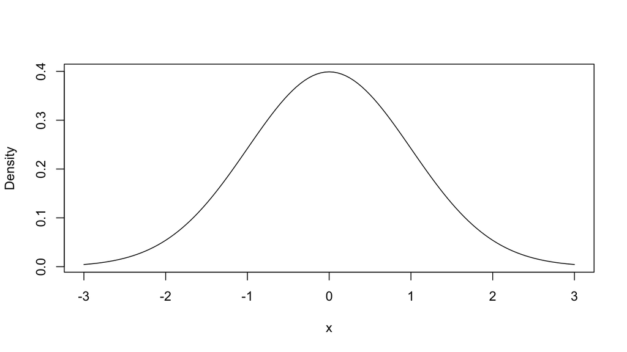

```r
x <- seq(from = -3, to = 3, by = 0.05)
y <- dnorm(x, mean = 0, sd = 1)
plot(x, y, type = "l", ylab = "Density")
```

## Standard Normal Distribution

- Generate 10 independent random numbers from a standard normal distribution

```r
str(rnorm) # generate random number from normal dist
```

```
## function (n, mean = 0, sd = 1)
```

```r
rnorm(10, mean = 0, sd = 1)
```

```
##  [1]  0.43956318 -1.64485575  0.20842655  0.04630707  0.24656529
##  [6]  0.49382761 -0.08550644 -0.12750461 -2.60386289 -0.23665443
```

## Standard Normal Distribution

- Calculate the probability that $X \leq 0$

```r
str(pnorm) # normal CDF
```

```
## function (q, mean = 0, sd = 1, lower.tail = TRUE, log.p = FALSE)
```

```r
pnorm(0, mean = 0, sd = 1) # Pr[X <= 0] = ?
```

```
## [1] 0.5
```

## Standard Normal Distribution

- Find the value for which the CDF = 0.975

```r
str(qnorm) # normal quantile func
```

```
## function (p, mean = 0, sd = 1, lower.tail = TRUE, log.p = FALSE)
```

```r
qnorm(0.975, mean = 0, sd = 1) # PR[X <= ?] = 0.975
```

```
## [1] 1.959964
```

## T-Tests

T-tests can be used to draw statistical conclusions about parameters of interest in the data

- Is the mean of this data different from zero (or another number)?
- Are the means of two data sets different from one another?
- Is the regression slope coefficient different from zero?

T-tests can be categorized into two groups:

1. One-sample t-test
2. Two-sample t-test

## One-Sample T-Test (Create Data)

```r
set.seed(123)
oneSampData <- rnorm(100, mean = 0, sd = 1)
mean(oneSampData)
```

```
## [1] 0.09040591
```

```r
sd(oneSampData)
```

```
## [1] 0.9128159
```

## One-Sample T-Test ($H_0: \mu = 0$)

```r
oneSampTest.0 <- t.test(oneSampData)
oneSampTest.0
```

```
##
##  One Sample t-test
##
## data:  oneSampData
## t = 0.99041, df = 99, p-value = 0.3244
## alternative hypothesis: true mean is not equal to 0
## 95 percent confidence interval:
##  -0.09071657  0.27152838
## sample estimates:
##  mean of x
## 0.09040591
```

```r
names(oneSampTest.0)
```

```
## [1] "statistic"   "parameter"   "p.value"     "conf.int"    "estimate"
## [6] "null.value"  "alternative" "method"      "data.name"
```

```r
oneSampTest.0$statistic
```

```
##         t
## 0.9904068
```

```r
oneSampTest.0$estimate
```

```
##  mean of x
## 0.09040591
```

## One-Sample T-Test ($H_0: \mu = a$)

```r
a <- 0.3
oneSampTest.mu <- t.test(oneSampData, mu = a)
oneSampTest.mu
```

```
##
##  One Sample t-test
##
## data:  oneSampData
## t = -2.2961, df = 99, p-value = 0.02378
## alternative hypothesis: true mean is not equal to 0.3
## 95 percent confidence interval:
##  -0.09071657  0.27152838
## sample estimates:
##  mean of x
## 0.09040591
```

## Two-Sample T-Test

Two sample t-tests are categorized into 3 groups:

- T-Test with equal variances
- T-Test with un-equal variances
- Paired T-Test (one-sample t-test on differences)

## Two-Sample T-Test (Create & Plot Data)

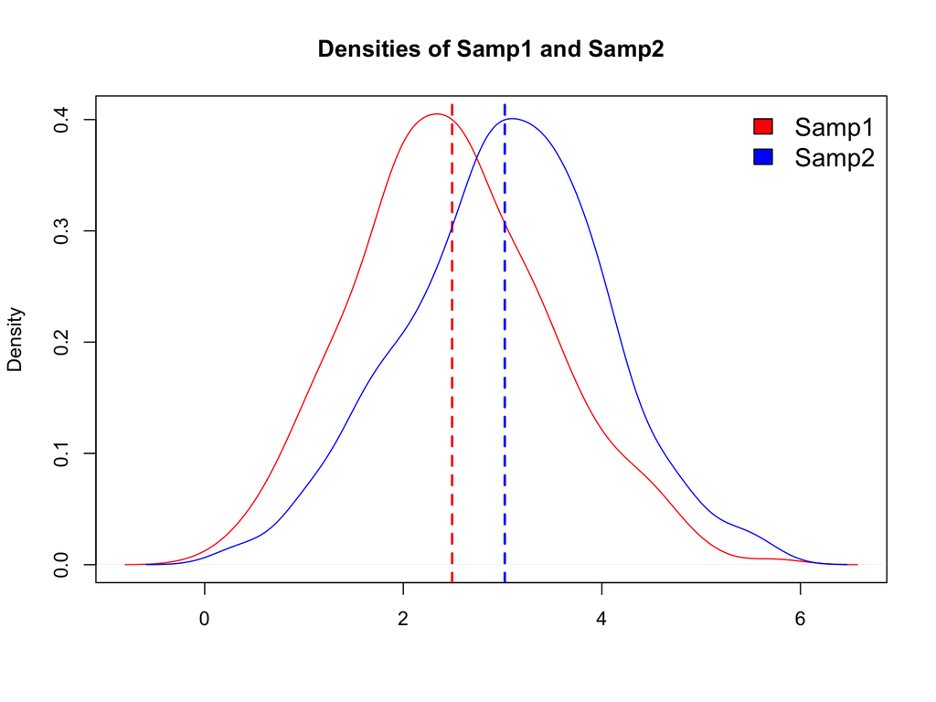

```r
Samp1 <- rnorm(300, mean = 2.5, sd = 1)
Samp2 <- rnorm(500, mean = 3.0, sd = 1) # notice: not the same sample size
plot(density(Samp1), col="red", main="Densities of Samp1 and Samp2", xlab="")
abline(v = mean(Samp1), col = "red", lwd = 2, lty=2)
lines(density(Samp2), col="blue")
abline(v = mean(Samp2), col = "blue", lwd = 2, lty = 2)
legend("topright", legend = c("Samp1", "Samp2"),
       fill = c("red","blue"), bty = "n", cex = 1.3)
```

## Two-Sample T-Test (Un-equal Variances)

Null hypothesis: $\mu_1 = \mu_2 \Leftrightarrow \mu_1 - \mu_2 = 0$

```r
t.test(Samp1, Samp2)  # default assump: unequal variances
```

```
##
##  Welch Two Sample t-test
##
## data:  Samp1 and Samp2
## t = -7.3058, df = 638.78, p-value = 8.249e-13
## alternative hypothesis: true difference in means is not equal to 0
## 95 percent confidence interval:
##  -0.6730166 -0.3878678
## sample estimates:
## mean of x mean of y
##  2.492232  3.022674
```

## Two-Sample T-Test (Equal Variances)

Null hypothesis: $\mu_1 = \mu_2 \Leftrightarrow \mu_1 - \mu_2 = 0$

```r
t.test(Samp1, Samp2, var.equal = TRUE)  # default assump: unequal variances
```

```
##
##  Two Sample t-test
##
## data:  Samp1 and Samp2
## t = -7.2723, df = 798, p-value = 8.447e-13
## alternative hypothesis: true difference in means is not equal to 0
## 95 percent confidence interval:
##  -0.6736199 -0.3872646
## sample estimates:
## mean of x mean of y
##  2.492232  3.022674
```

## Two-Sample T-Test (Paired T-Test)

Let $D \equiv \{x_i - y_i : i=1, \ldots, n \}$.

Null hypothesis: $\mu_D = 0$

```r
t.test(Samp1, Samp2[1:300], paired = TRUE) # must be of the same sample size
```

```
##
##  Paired t-test
##
## data:  Samp1 and Samp2[1:300]
## t = -5.7581, df = 299, p-value = 2.109e-08
## alternative hypothesis: true difference in means is not equal to 0
## 95 percent confidence interval:
##  -0.6428004 -0.3153406
## sample estimates:
## mean of the differences
##              -0.4790705
```

## Linear Regression

- Approach to model the relationship between a *response* variable $Y$ and one or more *predictor* variables $X$.
- $Y$ is a noisy linear combination of $X$:
  $$Y = X \beta + \epsilon$$
  - $Y$ is a $n \times 1$ vector of response variables
  - $X$ is a $n \times p$ matrix where each row $X_i$ is the predictor variables for the $i^{th}$ observation
  - $\beta$ is the $p \times 1$ vector of regression coefficients
  - $\epsilon \sim N(0,\sigma^2 I)$ is the $n \times 1$ error vector
  - Implies that $Y \sim N(X\beta, \sigma^2I)$
- Linear regression equivalent to modeling the mean of $Y$. Namely, $\mu = E(Y) = X\beta$
- Multiple ways to estimate $\beta$, but we will focus on the most basic method which is **ordinary least squares estimation**.
  - Minimize sum of squared error (SSE): $\sum_{i=1}^{n} (y_i - X_i\beta)^2$
  - Closed form solution: $\hat{\beta} = (X^T X)^{-1} X^T Y$
  - Unbiased and consistent

## Linear Regression in R

- We use `lm()` to fit linear regression models, which has requires us to pass in a regression formula.
- Don’t need to create the matrix $X$ (R does this for us), just tell it which predictors to include.
- Some notes on `formula`:
  - Response variable goes on the left and the predictors go on the right of a `~`
  - Predictors are separated by `+` symbols (e.g., `y ~ x + z`)
  - If you want to use all variables in a data frame, simply use `.` (e.g., `y ~ .`)
  - By default, the formula contains an intercept. If you want to exclude it (i.e., force the intercept to be zero), can use either of `y ~ 0 + .` or `y ~ . - 1`
  - Can include polynomial terms: Say we want to have a quadratic regression of `y` on `x`, we simply use `y ~ x + I(x^2)`

## Linear Regression - Prestige Data

We will fit a linear model using the prestige data. Recall that we have the following variables

- `education`: Average education of occupational incumbents, years, in 1971.
- `income`: Average income of incumbents, dollars, in 1971.
- `women`: Percentage of incumbents who are women.
- `prestige`: Pineo-Porter prestige score for occupation, from a social survey conducted in the mid-1960s.
- `census`: Canadian Census occupational code.
- `type`: Type of occupation, a factor with levels
  - `bc`: Blue Collar
  - `prof`: Professional, Managerial, and Technical
  - `wc`: White Collar

## Load Data

```r
prestige <- read.csv(file="./data/prestige_v2.csv", row.names=1)
str(prestige)
```

```
## 'data.frame':    101 obs. of  6 variables:
##  $ education: num  13.1 12.3 12.8 11.4 14.6 ...
##  $ income   : int  12351 25879 9271 8865 8403 11030 8258 14163 11377 11023 ...
##  $ women    : num  11.16 4.02 15.7 9.11 11.68 ...
##  $ prestige : num  68.8 69.1 63.4 56.8 73.5 77.6 72.6 78.1 73.1 68.8 ...
##  $ census   : int  1113 1130 1171 1175 2111 2113 2133 2141 2143 2153 ...
##  $ type     : Factor w/ 3 levels "bc","prof","wc": 2 2 2 2 2 2 2 2 2 2 ...
```

```r
head(prestige)
```

```
##                     education income women prestige census type
## gov.administrators      13.11  12351 11.16     68.8   1113 prof
## general.managers        12.26  25879  4.02     69.1   1130 prof
## accountants             12.77   9271 15.70     63.4   1171 prof
## purchasing.officers     11.42   8865  9.11     56.8   1175 prof
## chemists                14.62   8403 11.68     73.5   2111 prof
## physicists              15.64  11030  5.13     77.6   2113 prof
```

## Another look at the scatterplot matrix

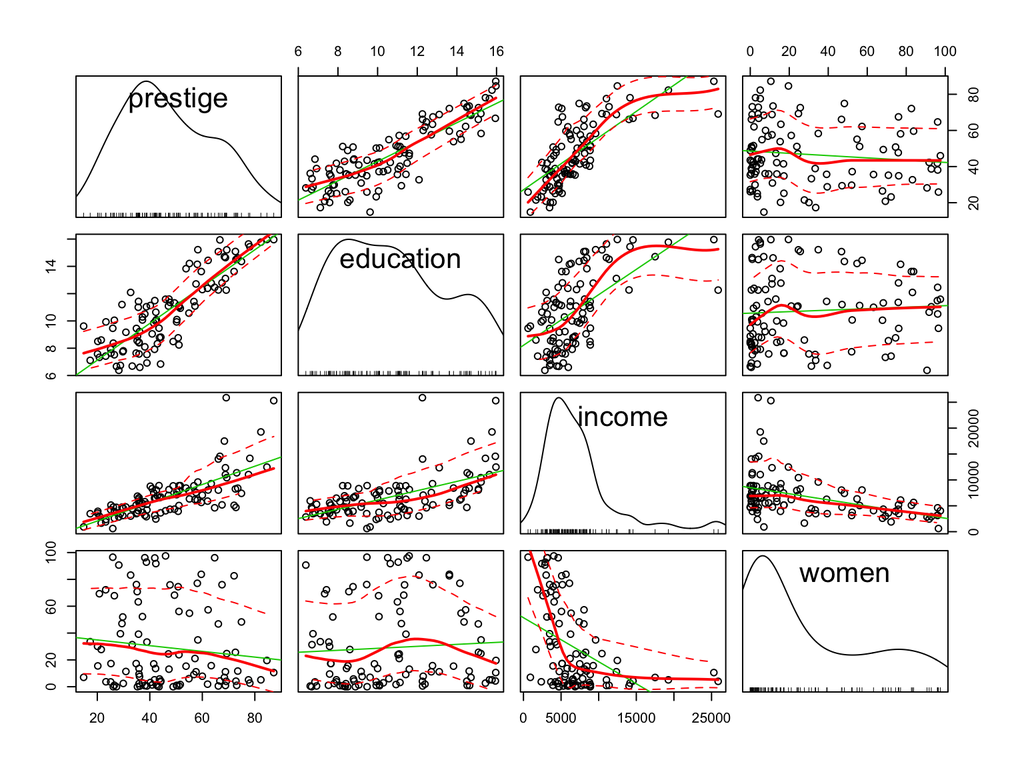

```r
library(car)
scatterplotMatrix(prestige[,c("prestige","education","income","women")])
```

## Linear Regression - Fit the Model

```r
myReg <- lm(prestige ~ education + income + women, data = prestige)
myReg
```

```
##
## Call:
## lm(formula = prestige ~ education + income + women, data = prestige)
##
## Coefficients:
## (Intercept)    education       income        women
##   -6.801684     4.182482     0.001315    -0.008304
```

```r
names(myReg)
```

```
##  [1] "coefficients"  "residuals"     "effects"       "rank"
##  [5] "fitted.values" "assign"        "qr"            "df.residual"
##  [9] "xlevels"       "call"          "terms"         "model"
```

## Linear Regression - Summary of Fit

```r
summary(myReg)
```

```
##
## Call:
## lm(formula = prestige ~ education + income + women, data = prestige)
##
## Residuals:
##      Min       1Q   Median       3Q      Max
## -19.7831  -5.4102  -0.1204   5.1821  17.5318
##
## Coefficients:
##               Estimate Std. Error t value Pr(>|t|)
## (Intercept) -6.8016842  3.2543983  -2.090   0.0392 *
## education    4.1824817  0.3907842  10.703  < 2e-16 ***
## income       0.0013153  0.0002791   4.712  8.2e-06 ***
## women       -0.0083038  0.0306187  -0.271   0.7868
## ---
## Signif. codes:  0 '***' 0.001 '**' 0.01 '*' 0.05 '.' 0.1 ' ' 1
##
## Residual standard error: 7.883 on 97 degrees of freedom
## Multiple R-squared:  0.798,  Adjusted R-squared:  0.7917
## F-statistic: 127.7 on 3 and 97 DF,  p-value: < 2.2e-16
```

## Linear Regression - Summary Contents

```r
myReg.summary <- summary(myReg)
names(myReg.summary) # show different contents
```

```
##  [1] "call"          "terms"         "residuals"     "coefficients"
##  [5] "aliased"       "sigma"         "df"            "r.squared"
##  [9] "adj.r.squared" "fstatistic"    "cov.unscaled"
```

```r
names(myReg) # this is what we had previously
```

```
##  [1] "coefficients"  "residuals"     "effects"       "rank"
##  [5] "fitted.values" "assign"        "qr"            "df.residual"
##  [9] "xlevels"       "call"          "terms"         "model"
```

## Linear Regression - Confidence Intervals

- 95% confidence interval for coefficient of `income`

```r
confint(myReg, 'income', level=0.95)
```

```
##              2.5 %      97.5 %
## income 0.000761253 0.001869315
```

- 95% confidence interval for each coefficient

```r
confint(myReg, level=0.95)
```

```
##                     2.5 %       97.5 %
## (Intercept) -13.260764035 -0.342604455
## education     3.406883236  4.958080173
## income        0.000761253  0.001869315
## women        -0.069073423  0.052465913
```

## Linear Regression - Adding Variables

Recall that `type` of occupation has a relationship with prestige score.

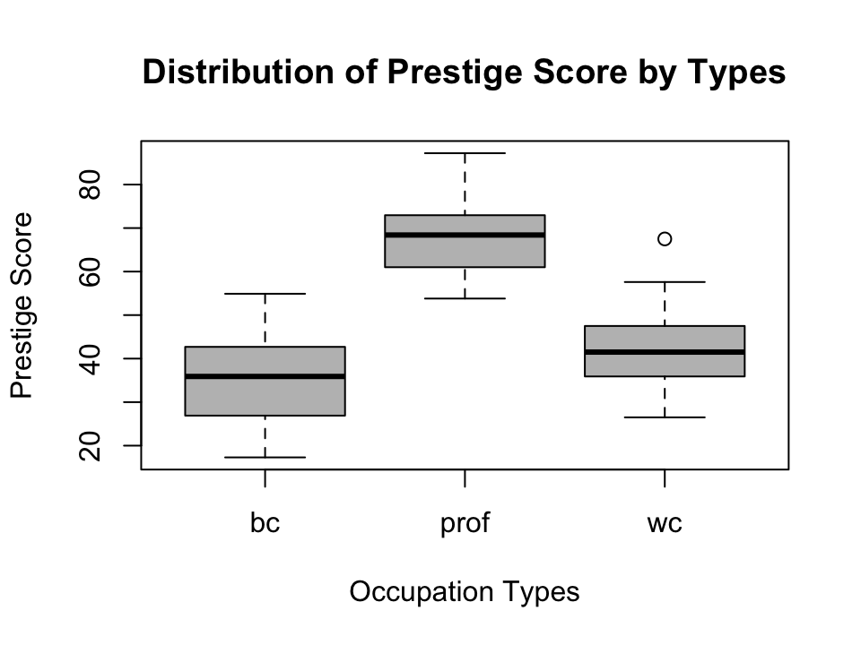

So let’s add the predictor `type` into our regression model:

```r
mod <- update(myReg, ~ . + type)
summary(mod)
```

```
##
## Call:
## lm(formula = prestige ~ education + income + women + type, data = prestige)
##
## Residuals:
##      Min       1Q   Median       3Q      Max
## -19.1126  -4.9844   0.0942   5.1318  19.4630
##
## Coefficients:
##               Estimate Std. Error t value Pr(>|t|)
## (Intercept)  2.7378124  5.5112850   0.497   0.6205
## education    3.1246575  0.6644750   4.702 8.70e-06 ***
## income       0.0011764  0.0002702   4.355 3.36e-05 ***
## women        0.0050863  0.0308647   0.165   0.8695
## typeprof     8.5502774  4.0724806   2.100   0.0384 *
## typewc      -1.1457779  2.7280276  -0.420   0.6754
## ---
## Signif. codes:  0 '***' 0.001 '**' 0.01 '*' 0.05 '.' 0.1 ' ' 1
##
## Residual standard error: 7.536 on 95 degrees of freedom
## Multiple R-squared:  0.8192, Adjusted R-squared:  0.8097
## F-statistic:  86.1 on 5 and 95 DF,  p-value: < 2.2e-16
```

## Linear Regression - Comparing Models

Suppose we want to test which of our two models is better when one model is *nested* within the other (i.e., both models contain the same terms and one has at least one additional term).

```r
formula(myReg)
```

```
## prestige ~ education + income + women
## <environment: 0x119a38df0>
```

```r
formula(mod)
```

```
## prestige ~ education + income + women + type
## <environment: 0x119a38df0>
```

We say that `myReg` is *nested within* `mod`, or equivantley that `myReg` is the **reduced** model and `mod` is the **full** model.

Hypothesis Test:

- Null: Reduced model fits as well as the full model (formally, coefficients for the omitted terms are all zero).
- Alternative: Full model fits better than the reduced model (formally, at least one omitted coefficient is non-zero).

## Linear Regression - Comparing Models, contd.

```r
anova(myReg, mod)
```

```
## Analysis of Variance Table
##
## Model 1: prestige ~ education + income + women
## Model 2: prestige ~ education + income + women + type
##   Res.Df    RSS Df Sum of Sq      F   Pr(>F)
## 1     97 6028.2
## 2     95 5394.6  2     633.6 5.5789 0.005119 **
## ---
## Signif. codes:  0 '***' 0.001 '**' 0.01 '*' 0.05 '.' 0.1 ' ' 1
```

So we reject the null hypothesis and conclude that at least one of the levels of type of occupation contributes information about the prestige score.

## Linear Regression - Relevel a Factor

Say we want the change the reference level for the covariate `type` so that the intercept of the model includes is for professionals. We simply relevel the variable `type` and re-fit the model.

```r
levels(prestige$type)
```

```
## [1] "bc"   "prof" "wc"
```

```r
prestige$type <- relevel(prestige$type, "prof")
levels(prestige$type)
```

```
## [1] "prof" "bc"   "wc"
```

**Note: This does not change the results of the model (e.g., predictions, F-statistics) but does change the interpretation and p-values of the type coefficients.**

## Linear Regression - Relevel a Factor, contd.

```r
mod <- update(myReg, ~ . + type)
summary(mod)
```

```
##
## Call:
## lm(formula = prestige ~ education + income + women + type, data = prestige)
##
## Residuals:
##      Min       1Q   Median       3Q      Max
## -19.1126  -4.9844   0.0942   5.1318  19.4630
##
## Coefficients:
##               Estimate Std. Error t value Pr(>|t|)
## (Intercept) 11.2880898  9.1659054   1.232  0.22116
## education    3.1246575  0.6644750   4.702 8.70e-06 ***
## income       0.0011764  0.0002702   4.355 3.36e-05 ***
## women        0.0050863  0.0308647   0.165  0.86946
## typebc      -8.5502774  4.0724806  -2.100  0.03842 *
## typewc      -9.6960553  2.9391152  -3.299  0.00137 **
## ---
## Signif. codes:  0 '***' 0.001 '**' 0.01 '*' 0.05 '.' 0.1 ' ' 1
##
## Residual standard error: 7.536 on 95 degrees of freedom
## Multiple R-squared:  0.8192, Adjusted R-squared:  0.8097
## F-statistic:  86.1 on 5 and 95 DF,  p-value: < 2.2e-16
```

## Linear Regression - More on Variable Selection

- Automated algorithms for automatic variable selection exist, but should be used with caution.
- Better to start with an *a priori* set of variables you need to include and then compare models, especially when goal is assocation instead of prediction.
- **Stepwise regression**: start with a model and add (or remove) predictors until some criteria is met

```r
null <- lm(prestige ~ 1, data=prestige)  # most basic model, intercept only
full <- lm(prestige ~ education + income + women + type, data=prestige)  # saturated model, all predictors
step(null, scope=list(lower=null, upper=full), direction='forward')
```

```
## Start:  AIC=576.54
## prestige ~ 1
##
##             Df Sum of Sq     RSS    AIC
## + education  1   21567.5  8274.6 448.99
## + type       2   20685.1  9157.0 461.22
## + income     1   15236.2 14605.9 506.38
## <none>                   29842.1 576.54
## + women      1     400.9 29441.1 577.18
##
## Step:  AIC=448.99
## prestige ~ education
##
##          Df Sum of Sq    RSS    AIC
## + income  1   2241.78 6032.8 419.07
## + type    2   1428.45 6846.1 433.85
## + women   1    866.64 7407.9 439.81
## <none>                8274.6 448.99
##
## Step:  AIC=419.07
## prestige ~ education + income
##
##         Df Sum of Sq    RSS    AIC
## + type   2    636.63 5396.2 411.81
## <none>               6032.8 419.07
## + women  1      4.57 6028.2 421.00
##
## Step:  AIC=411.81
## prestige ~ education + income + type
##
##         Df Sum of Sq    RSS    AIC
## <none>               5396.2 411.81
## + women  1    1.5421 5394.6 413.78
```

```
##
## Call:
## lm(formula = prestige ~ education + income + type, data = prestige)
##
## Coefficients:
## (Intercept)    education       income       typebc       typewc
##   11.520005     3.135291     0.001153    -8.646693    -9.655940
```

```r
step(full, scope=list(lower=null, upper=full), direction='backward')
```

```
## Start:  AIC=413.78
## prestige ~ education + income + women + type
##
##             Df Sum of Sq    RSS    AIC
## - women      1      1.54 5396.2 411.81
## <none>                   5394.6 413.78
## - type       2    633.60 6028.2 421.00
## - income     1   1076.80 6471.4 430.16
## - education  1   1255.70 6650.3 432.92
##
## Step:  AIC=411.81
## prestige ~ education + income + type
##
##             Df Sum of Sq    RSS    AIC
## <none>                   5396.2 411.81
## - type       2    636.63 6032.8 419.07
## - education  1   1276.30 6672.5 431.25
## - income     1   1449.96 6846.1 433.85
```

```
##
## Call:
## lm(formula = prestige ~ education + income + type, data = prestige)
##
## Coefficients:
## (Intercept)    education       income       typebc       typewc
##   11.520005     3.135291     0.001153    -8.646693    -9.655940
```

```r
step(null, scope=list(lower=null, upper=full), direction='both')
```

```
## Start:  AIC=576.54
## prestige ~ 1
##
##             Df Sum of Sq     RSS    AIC
## + education  1   21567.5  8274.6 448.99
## + type       2   20685.1  9157.0 461.22
## + income     1   15236.2 14605.9 506.38
## <none>                   29842.1 576.54
## + women      1     400.9 29441.1 577.18
##
## Step:  AIC=448.99
## prestige ~ education
##
##             Df Sum of Sq     RSS    AIC
## + income     1    2241.8  6032.8 419.07
## + type       2    1428.5  6846.1 433.85
## + women      1     866.6  7407.9 439.81
## <none>                    8274.6 448.99
## - education  1   21567.5 29842.1 576.54
##
## Step:  AIC=419.07
## prestige ~ education + income
##
##             Df Sum of Sq     RSS    AIC
## + type       2     636.6  5396.2 411.81
## <none>                    6032.8 419.07
## + women      1       4.6  6028.2 421.00
## - income     1    2241.8  8274.6 448.99
## - education  1    8573.1 14605.9 506.38
##
## Step:  AIC=411.81
## prestige ~ education + income + type
##
##             Df Sum of Sq    RSS    AIC
## <none>                   5396.2 411.81
## + women      1      1.54 5394.6 413.78
## - type       2    636.63 6032.8 419.07
## - education  1   1276.30 6672.5 431.25
## - income     1   1449.96 6846.1 433.85
```

```
##
## Call:
## lm(formula = prestige ~ education + income + type, data = prestige)
##
## Coefficients:
## (Intercept)    education       income       typebc       typewc
##   11.520005     3.135291     0.001153    -8.646693    -9.655940
```

## Linear Regression - More on Variable Selection

- **All subsets regression**: test all possible subsets of the predictors
  - $p$ predictors $\Rightarrow 2^p$ combinations
  - Pick the best model based on some well-defined criteria
  - Pro: Exhaustive
  - Con: Computationally expensive
- **Best subsets regression**: similar to all subsets, but only look at the best model of each size
- Multiple packages can do this, but we will use `leaps`

```r
if (!require("leaps")) install.packages("leaps")  # install leaps if it isn't already
library(leaps)
bestSubsets <- regsubsets(prestige ~ education + income + women + type, data=prestige, nbest=1)
summary(bestSubsets)
```

```
## Subset selection object
## Call: .f(.x[[i]], ...)
## 5 Variables  (and intercept)
##           Forced in Forced out
## education     FALSE      FALSE
## income        FALSE      FALSE
## women         FALSE      FALSE
## typebc        FALSE      FALSE
## typewc        FALSE      FALSE
## 1 subsets of each size up to 5
## Selection Algorithm: exhaustive
##          education income women typebc typewc
## 1  ( 1 ) "*"       " "    " "   " "    " "
## 2  ( 1 ) "*"       "*"    " "   " "    " "
## 3  ( 1 ) "*"       "*"    " "   " "    "*"
## 4  ( 1 ) "*"       "*"    " "   "*"    "*"
## 5  ( 1 ) "*"       "*"    "*"   "*"    "*"
```

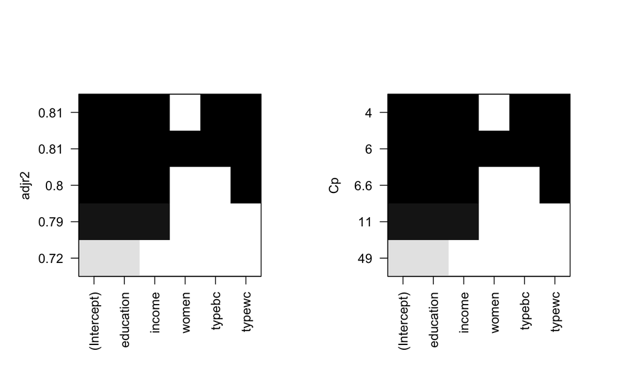

```r
par(mfrow=c(1,2))
plot(bestSubsets, scale="adjr2"); plot(bestSubsets, scale="Cp")
```

Note: The plot on the right is Mallow’s $C_p$, which is a statistic used to compare models that accounts for the number of predictors in the model (we want it to be roughly equal to the number of predictors included in the model).

## Linear Regression - Diagnostics

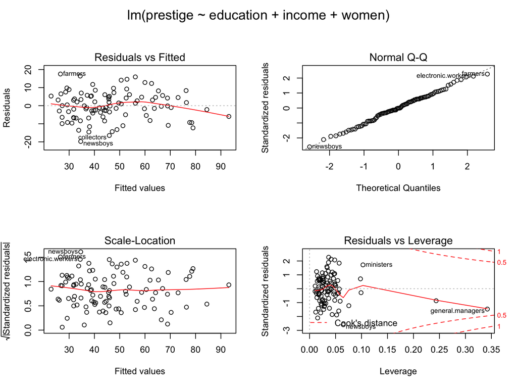

```r
par(mfrow = c(2, 2), oma = c(0, 0, 2, 0))
plot(myReg)
```

## Linear Regression - Prediction

Predict the output for a new input

```r
newData = data.frame(education=13.2, income=12000, women=12)
predict(myReg, newData, interval="predict")
```

```
##        fit     lwr      upr
## 1 64.09084 48.2459 79.93578
```

## End of Session 3

Next up:

1. [Exercise 3](https://ucidatascienceinitiative.github.io//IDA-with-R/Exercises/IDA-with-R_Exercise_3.html)
2. Break

**Return at 3:30 to discuss solutions to Exercise 3!**